# Assignment4

Yuhong Zhao

2/14/2022

## Question: Does the season affect the subway ridership in Boston?

Data source: https://mbta-massdot.opendata.arcgis.com/datasets/mbta-monthly-ridership-by-mode/explore

The data set contains total monthly ridership of all modes of transportation of the MBTA from January 2016 to December 2021. However, for this question, we are interested in only the orange subway line of the MBTA system. We are curious on how the season affect the ridership of the orange line.

```r
transitData <- read.csv("MBTA_DATA.csv")

head(transitData)
```

```
##          ï..service_date          mode route_or_line
## 1 2016/01/01 05:00:00+00          Rail     Blue Line
## 2 2016/01/01 05:00:00+00         Ferry       Boat-F1
## 3 2016/01/01 05:00:00+00         Ferry       Boat-F3
## 4 2016/01/01 05:00:00+00         Ferry       Boat-F4
## 5 2016/01/01 05:00:00+00           Bus           Bus
## 6 2016/01/01 05:00:00+00 Commuter Rail Commuter Rail
##   total_monthly_weekday_ridership average_monthly_weekday_ridersh
## 1                         1145383                           60283
## 2                           59503                            2975
## 3                           16191                             810
## 4                            8172                             409
## 5                         6985521                          367659
## 6                         2827718                          134653
##   countofdates_weekday total_monthly_ridership average_monthly_ridership
## 1                   19                 1570201                     50652
## 2                   20                      NA                        NA
## 3                   20                      NA                        NA
## 4                   20                      NA                        NA
## 5                   19                 8225148                    265328
## 6                   21                 2794459                     90144
##   countofdates ObjectId
## 1           31        1
## 2           31        2
## 3           31        3
## 4           31        4
## 5           31        5
## 6           31        6
```

Here we are importing the libraries we will need. The ggplot2 library will be necessary to create graphs and visualization from our data, while the Tidyverse library will be used as a tool to manipulate and clean up our data.

```r
library(ggplot2)
library(tidyverse)
```

## Cleaning up the data

Our data contains the monthly ridership numbers for all modes of transportation under the MBTA, which includes the Ferry, Bus, Commuter rail as well as other subway lines. In this case, we are only interested in the data for the orange line. We can first filter out the data to only keep data about the orange line using Tidyverse.

```r
# filter the column "route_or_line" to only values of "Orange Line"
orangeLine <- transitData %>% filter(route_or_line == "Orange Line")

head(orangeLine)
```

```
##          ï..service_date mode route_or_line total_monthly_weekday_ridership
## 1 2016/01/01 05:00:00+00 Rail   Orange Line                         4094142
## 2 2016/02/01 05:00:00+00 Rail   Orange Line                         4360890
## 3 2016/03/01 05:00:00+00 Rail   Orange Line                         5092407
## 4 2016/04/01 04:00:00+00 Rail   Orange Line                         4643144
## 5 2016/10/01 04:00:00+00 Rail   Orange Line                         4614199
## 6 2016/11/01 04:00:00+00 Rail   Orange Line                         4462162
##   average_monthly_weekday_ridersh countofdates_weekday total_monthly_ridership
## 1                          215481                   19                 5277916
## 2                          218045                   20                 5222213
## 3                          221409                   23                 5893406
## 4                          221102                   21                 5577147
## 5                          219724                   21                 5581444
## 6                          212484                   21                 5257747
##   average_monthly_ridership countofdates ObjectId
## 1                    170255           31        8
## 2                    180076           29       19
## 3                    190110           31       30
## 4                    185905           30       41
## 5                    180047           31       56
## 6                    175258           30       68
```

Next, we can sort the data by the date (oldest to newest) so we can interpret the data better and once we graph our data using ggplot, it should be in order by months. We will use the arrange function from tidyverse to sort.

```r
# sort the date using arrange function
orangeLineSort <- orangeLine  %>% arrange(ï..service_date)

head(orangeLineSort)
```

```
##          ï..service_date mode route_or_line total_monthly_weekday_ridership
## 1 2016/01/01 05:00:00+00 Rail   Orange Line                         4094142
## 2 2016/02/01 05:00:00+00 Rail   Orange Line                         4360890
## 3 2016/03/01 05:00:00+00 Rail   Orange Line                         5092407
## 4 2016/04/01 04:00:00+00 Rail   Orange Line                         4643144
## 5 2016/05/01 04:00:00+00 Rail   Orange Line                         4590972
## 6 2016/06/01 04:00:00+00 Rail   Orange Line                         4817580
##   average_monthly_weekday_ridersh countofdates_weekday total_monthly_ridership
## 1                          215481                   19                 5277916
## 2                          218045                   20                 5222213
## 3                          221409                   23                 5893406
## 4                          221102                   21                 5577147
## 5                          218618                   21                 5499944
## 6                          218981                   22                 5521627
##   average_monthly_ridership countofdates ObjectId
## 1                    170255           31        8
## 2                    180076           29       19
## 3                    190110           31       30
## 4                    185905           30       41
## 5                    177418           31      152
## 6                    184054           30      163
```

Once we have cleaned up our data, we can break up the data and store them into each variable. We will extract data from each year and store them into their own variable. Then, we can add a column with a number of each corresponding month. We will also need to factor our new Month column since ggplot automatically sort our x axis, but our column is already sorted.

```r
# Filtering out 2016 data
orangeLine2016 <- orangeLineSort %>% filter(substr(ï..service_date, 1,4) == "2016")
# Add a month column into our data
orangeLine2016$Month <- c(1,2,3,4,5,6,7,8,9,10,11,12)
# Factor the month column
orangeLine2016$Month <- factor(orangeLine2016$Month)

head(orangeLine2016)
```

```
##          ï..service_date mode route_or_line total_monthly_weekday_ridership
## 1 2016/01/01 05:00:00+00 Rail   Orange Line                         4094142
## 2 2016/02/01 05:00:00+00 Rail   Orange Line                         4360890
## 3 2016/03/01 05:00:00+00 Rail   Orange Line                         5092407
## 4 2016/04/01 04:00:00+00 Rail   Orange Line                         4643144
## 5 2016/05/01 04:00:00+00 Rail   Orange Line                         4590972
## 6 2016/06/01 04:00:00+00 Rail   Orange Line                         4817580
##   average_monthly_weekday_ridersh countofdates_weekday total_monthly_ridership
## 1                          215481                   19                 5277916
## 2                          218045                   20                 5222213
## 3                          221409                   23                 5893406
## 4                          221102                   21                 5577147
## 5                          218618                   21                 5499944
## 6                          218981                   22                 5521627
##   average_monthly_ridership countofdates ObjectId Month
## 1                    170255           31        8     1
## 2                    180076           29       19     2
## 3                    190110           31       30     3
## 4                    185905           30       41     4
## 5                    177418           31      152     5
## 6                    184054           30      163     6
```

```r
# Filtering out 2017 data
orangeLine2017 <- orangeLineSort %>% filter(substr(ï..service_date, 1,4) == "2017")
# Add a month column into our data
orangeLine2017$Month <- c(1,2,3,4,5,6,7,8,9,10,11,12)
# Factor the month column
orangeLine2017$Month <- factor(orangeLine2017$Month)

head(orangeLine2017)
```

```
##          ï..service_date mode route_or_line total_monthly_weekday_ridership
## 1 2017/01/01 05:00:00+00 Rail   Orange Line                         4120364
## 2 2017/02/01 05:00:00+00 Rail   Orange Line                         3856132
## 3 2017/03/01 05:00:00+00 Rail   Orange Line                         4697647
## 4 2017/04/01 04:00:00+00 Rail   Orange Line                         4274634
## 5 2017/05/01 04:00:00+00 Rail   Orange Line                         4659776
## 6 2017/06/01 04:00:00+00 Rail   Orange Line                         4672258
##   average_monthly_weekday_ridersh countofdates_weekday total_monthly_ridership
## 1                          206018                   20                 5256904
## 2                          202954                   19                 4650824
## 3                          204246                   23                 5382112
## 4                          213732                   20                 5249509
## 5                          211808                   22                 5475148
## 6                          212375                   22                 5485035
##   average_monthly_ridership countofdates ObjectId Month
## 1                    159300           33       90     1
## 2                    166101           28      201     2
## 3                    173617           31      212     3
## 4                    174984           30      223     4
## 5                    176618           31      234     5
## 6                    182835           30      245     6
```

```r
# Filtering out 2018 data
orangeLine2018 <- orangeLineSort %>% filter(substr(ï..service_date, 1,4) == "2018")
# Add a month column into our data
orangeLine2018$Month <- c(1,2,3,4,5,6,7,8,9,10,11,12)
# Factor the month column
orangeLine2018$Month <- factor(orangeLine2018$Month)

head(orangeLine2018)
```

```
##          ï..service_date mode route_or_line total_monthly_weekday_ridership
## 1 2018/01/01 05:00:00+00 Rail   Orange Line                         3957517
## 2 2018/02/01 05:00:00+00 Rail   Orange Line                         3908354
## 3 2018/03/01 05:00:00+00 Rail   Orange Line                         4188913
## 4 2018/04/01 04:00:00+00 Rail   Orange Line                         4429086
## 5 2018/05/01 04:00:00+00 Rail   Orange Line                         4686529
## 6 2018/06/01 04:00:00+00 Rail   Orange Line                         4439933
##   average_monthly_weekday_ridersh countofdates_weekday total_monthly_ridership
## 1                          188453                   21                 4823779
## 2                          205703                   19                 4673470
## 3                          190405                   22                 5036651
## 4                          210909                   21                 5279513
## 5                          213024                   22                 5496141
## 6                          211425                   21                 5294948
##   average_monthly_ridership countofdates ObjectId Month
## 1                    146175           33      272     1
## 2                    166910           28      283     2
## 3                    162473           31      295     3
## 4                    175984           30      305     4
## 5                    177295           31      316     5
## 6                    176498           30      327     6
```

```r
# Filtering out 2019 data
orangeLine2019 <- orangeLineSort %>% filter(substr(ï..service_date, 1,4) == "2019")
# Add a month column into our data
orangeLine2019$Month <- c(1,2,3,4,5,6,7,8,9,10,11,12)
# Factor the month column
orangeLine2019$Month <- factor(orangeLine2019$Month)

head(orangeLine2019)
```

```
##          ï..service_date mode route_or_line total_monthly_weekday_ridership
## 1 2019/01/01 05:00:00+00 Rail   Orange Line                         4018095
## 2 2019/02/01 05:00:00+00 Rail   Orange Line                         3750434
## 3 2019/03/01 05:00:00+00 Rail   Orange Line                         4149675
## 4 2019/04/01 04:00:00+00 Rail   Orange Line                         4492199
## 5 2019/05/01 04:00:00+00 Rail   Orange Line                         4528759
## 6 2019/06/01 04:00:00+00 Rail   Orange Line                         4133422
##   average_monthly_weekday_ridersh countofdates_weekday total_monthly_ridership
## 1                          191338                   21                 4825535
## 2                          197391                   19                 4478617
## 3                          197604                   21                 4995474
## 4                          204191                   22                 5225079
## 5                          205853                   22                 5354899
## 6                          206671                   20                 5078315
##   average_monthly_ridership countofdates ObjectId Month
## 1                    155662           31      412     1
## 2                    159951           28      484     2
## 3                    161144           31      495     3
## 4                    174169           30      596     4
## 5                    172739           31      607     5
## 6                    169277           30      427     6
```

```r
# Filtering out 2020 data
orangeLine2020 <- orangeLineSort %>% filter(substr(ï..service_date, 1,4) == "2020")
# Add a month column into our data
orangeLine2020$Month <- c(1,2,3,4,5,6,7,8,9,10,11,12)
# Factor the month column
orangeLine2020$Month <- factor(orangeLine2020$Month)

head(orangeLine2020)
```

```
##          ï..service_date mode route_or_line total_monthly_weekday_ridership
## 1 2020/01/01 05:00:00+00 Rail   Orange Line                         4321818
## 2 2020/02/01 05:00:00+00 Rail   Orange Line                         3951653
## 3 2020/03/01 05:00:00+00 Rail   Orange Line                         2247958
## 4 2020/04/01 04:00:00+00 Rail   Orange Line                          383577
## 5 2020/05/01 04:00:00+00 Rail   Orange Line                          408104
## 6 2020/06/01 04:00:00+00 Rail   Orange Line                          717108
##   average_monthly_weekday_ridersh countofdates_weekday total_monthly_ridership
## 1                          205801                   21                 5111252
## 2                          207982                   19                 4614174
## 3                          102180                   22                 2645811
## 4                           17435                   22                  461404
## 5                           20405                   20                  545369
## 6                           32596                   22                  878741
##   average_monthly_ridership countofdates ObjectId Month
## 1                    164879           31      525     1
## 2                    159109           29      536     2
## 3                     85349           31      547     3
## 4                     15380           30      425     4
## 5                     17593           31      446     5
## 6                     29291           30      457     6
```

```r
# Filtering out 2021 data
orangeLine2021 <- orangeLineSort %>% filter(substr(ï..service_date, 1,4) == "2021")
# Add a month column into our data
orangeLine2021$Month <- c(1,2,3,4,5,6,7,8,9,10,11,12)
# Factor the month column
orangeLine2021$Month <- factor(orangeLine2021$Month)
head(orangeLine2021)
```

```
##          ï..service_date mode route_or_line total_monthly_weekday_ridership
## 1 2021/01/01 05:00:00+00 Rail   Orange Line                          902850
## 2 2021/02/01 05:00:00+00 Rail   Orange Line                          951911
## 3 2021/03/01 05:00:00+00 Rail   Orange Line                         1206853
## 4 2021/04/01 04:00:00+00 Rail   Orange Line                         1250603
## 5 2021/05/01 04:00:00+00 Rail   Orange Line                         1319598
## 6 2021/06/01 04:00:00+00 Rail   Orange Line                         1610703
##   average_monthly_weekday_ridersh countofdates_weekday total_monthly_ridership
## 1                           47518                   19                 1260968
## 2                           50101                   19                 1219121
## 3                           52472                   23                 1455806
## 4                           56846                   22                 1532138
## 5                           65980                   20                 1776863
## 6                           73214                   22                 1982030
##   average_monthly_ridership countofdates ObjectId Month
## 1                     40676           31      664     1
## 2                     43540           28      722     2
## 3                     46961           31      730     3
## 4                     51071           30      739     4
## 5                     57318           31      748     5
## 6                     66068           30      757     6
```

### Plotting using ggplot

We can plot the 2016 data on a bar plot to see how it looks like.

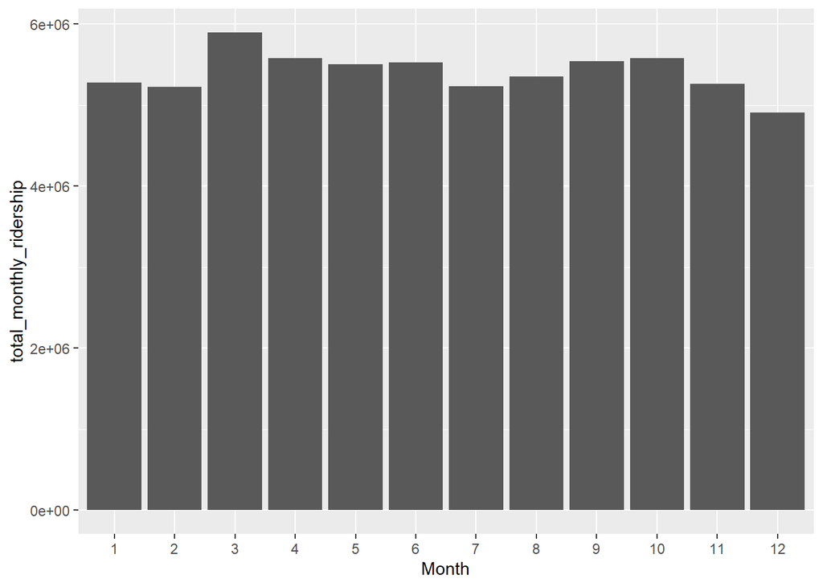

```r
# plotting using ggplot with the dates for x values and total riderships for y values
orangeLine2016Plot <- ggplot(data=orangeLine2016,aes(x= Month, y= total_monthly_ridership)) + geom_bar(stat="identity")
orangeLine2016Plot
```

This seems like a good start and we can also improve the visualization of our graph. First, we can improve and give a label for the y axis, add a title, and change the color of the bars.

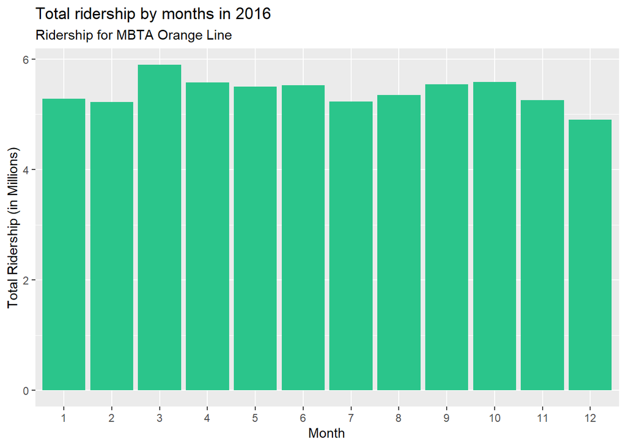

```r
orangeLine2016Plot <- orangeLine2016Plot +
  # changing the bar color
  geom_bar(stat="identity", fill = "#2BC58B") +
  # Changing the Y axis scale to millions
  scale_y_continuous(name = "Total Ridership (in Millions)",labels = function(x) x / 1000000) +
  # Adding a title
  labs(title = "Total ridership by months in 2016",
       subtitle ="Ridership for MBTA Orange Line")


orangeLine2016Plot
```

This looks good and we should plot the bar plot for 2017 - 2021.

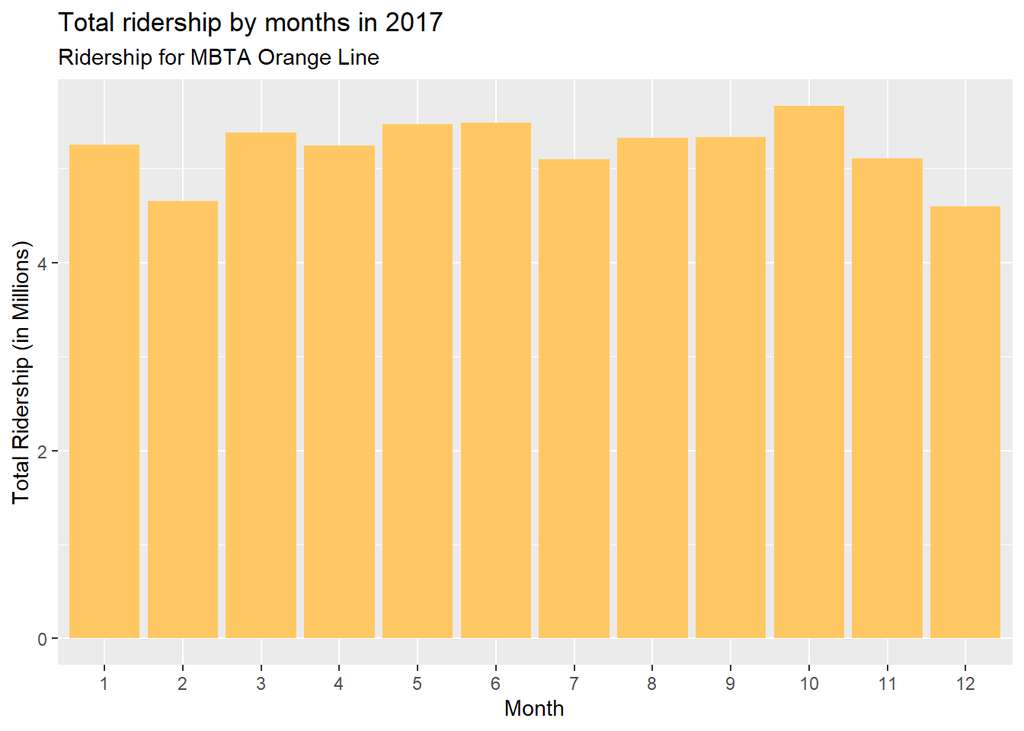

```r
# Plot for the 2017 data
orangeLine2017Plot <- ggplot(data=orangeLine2017,aes(x= Month, y= total_monthly_ridership)) +
  # changing the bar color
  geom_bar(stat="identity", fill = "#FFC863") +
  # Changing the Y axis scale to millions
  scale_y_continuous(name = "Total Ridership (in Millions)",labels = function(x) x / 1000000) +
  # Adding a title
  labs(title = "Total ridership by months in 2017",
       subtitle ="Ridership for MBTA Orange Line")

orangeLine2017Plot
```

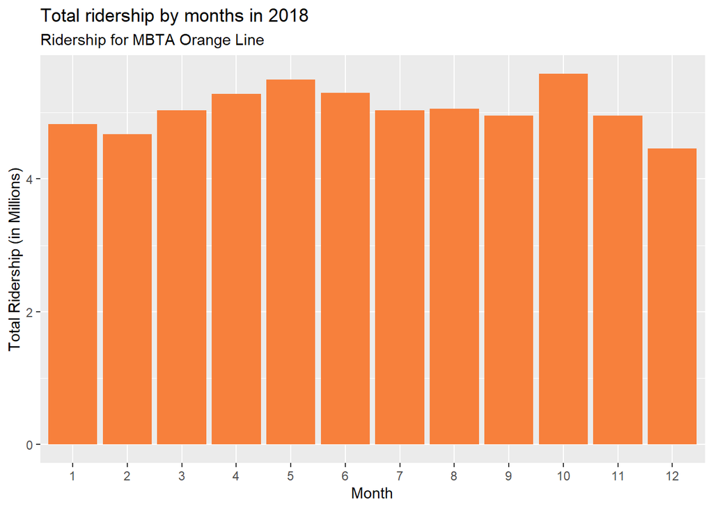

```r
# Plot for the 2018 data
orangeLine2018Plot <- ggplot(data=orangeLine2018,aes(x= Month, y= total_monthly_ridership)) +
  # changing the bar color
  geom_bar(stat="identity", fill = "#F7803C") +
  # Changing the Y axis scale to millions
  scale_y_continuous(name = "Total Ridership (in Millions)",labels = function(x) x / 1000000) +
  # Adding a title
  labs(title = "Total ridership by months in 2018",
       subtitle ="Ridership for MBTA Orange Line")

orangeLine2018Plot
```

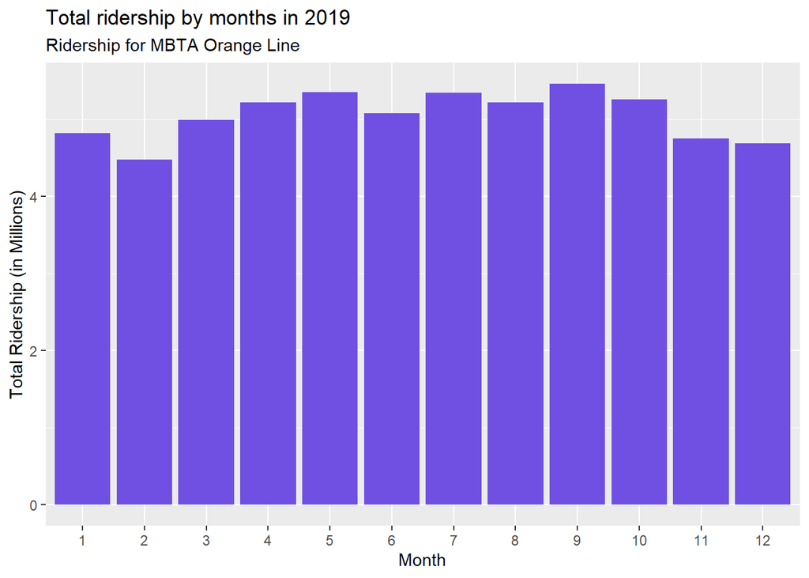

```r
# Plot for the 2019 data
orangeLine2019Plot <- ggplot(data=orangeLine2019,aes(x= Month, y= total_monthly_ridership)) +
  # changing the bar color
  geom_bar(stat="identity", fill = "#6F50E2") +
  # Changing the Y axis scale to millions
  scale_y_continuous(name = "Total Ridership (in Millions)",labels = function(x) x / 1000000) +
  # Adding a title
  labs(title = "Total ridership by months in 2019",
       subtitle ="Ridership for MBTA Orange Line")

orangeLine2019Plot
```

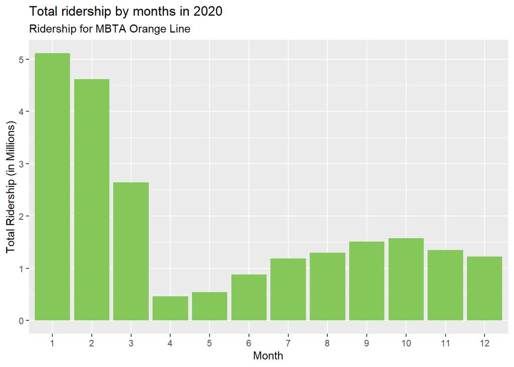

```r
# Plot for the 2020 data
orangeLine2020Plot <- ggplot(data=orangeLine2020,aes(x= Month, y= total_monthly_ridership)) +
  # changing the bar color
  geom_bar(stat="identity", fill = "#85C85A") +
  # Changing the Y axis scale to millions
  scale_y_continuous(name = "Total Ridership (in Millions)",labels = function(x) x / 1000000) +
  # Adding a title
  labs(title = "Total ridership by months in 2020",
       subtitle ="Ridership for MBTA Orange Line")

orangeLine2020Plot
```

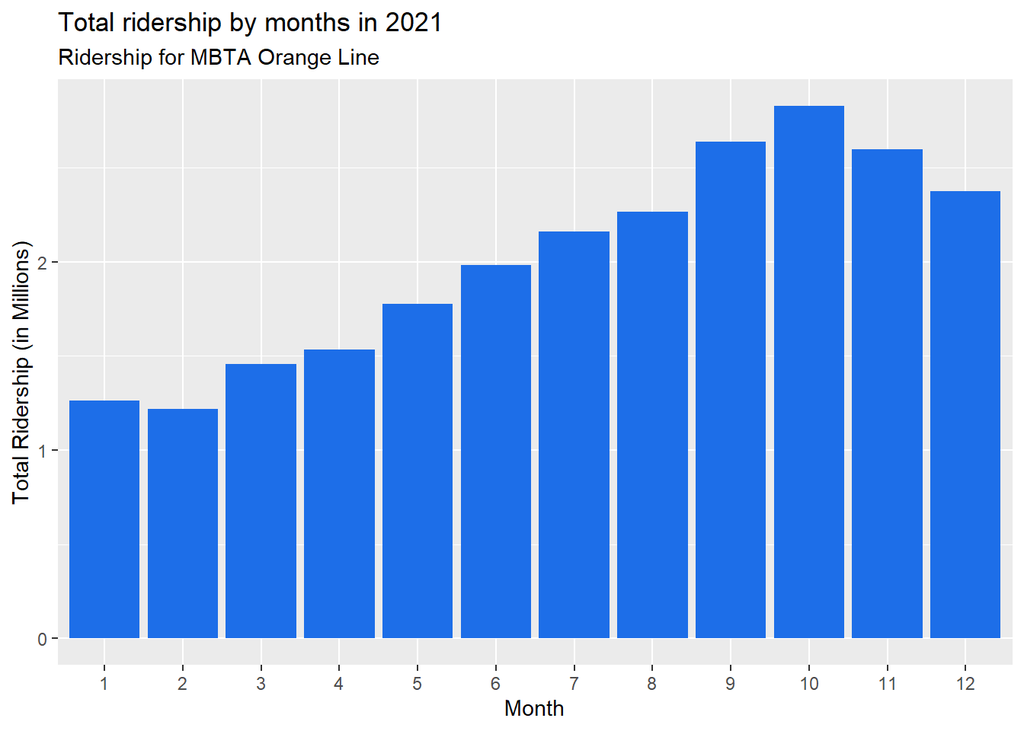

```r
# Plot for the 2021 data
orangeLine2021Plot <- ggplot(data=orangeLine2021,aes(x= Month, y= total_monthly_ridership)) +
  # changing the bar color
  geom_bar(stat="identity", fill = "#1D6EE8") +
  # Changing the Y axis scale to millions
  scale_y_continuous(name = "Total Ridership (in Millions)",labels = function(x) x / 1000000) +
  # Adding a title
  labs(title = "Total ridership by months in 2021",
       subtitle ="Ridership for MBTA Orange Line")

orangeLine2021Plot
```

# Analysis

In 2016, we can see that ridership number stayed nearly constant for the entire year, however there are two bumps occurring in the spring (April to June) and fall (September to November) season months. This pattern also occurred in 2017, 2018, and 2019. I suspect that this is due to the weather during these seasons where its more suitable for public transportation. It is also possible that it is due to the students in the Boston area since college takes place during those months and considering that Boston have a big student population.

The 2020 graph shows a big dip in ridership with January having over 5 million riders and April having about half a million riders. This is due to the Covid-19 pandemic where restrictions were in place to stop the spread. During the pandemic, most people transitioned to work from home, thus reducing the need to ride public transportation. However, we can see that towards the end of the year, there was bump in ridership during the fall season months. This is interesting despite the Covid-19 pandemic happening.

The 2021 graph shows mostly recovery towards pre-pandemic ridership numbers, however we see a decline in ridership in the last two months of the year. In the fall season months we again see that bump or bell shaped pattern.

From analyzing monthly ridership data of the MBTA Orange Line from 2016 to 2021, we can say that there is a correlation between the season and the total monthly ridership. Pre-pandemic years (2016-2019) shows a small bump increase in the ridership numbers during the spring and fall seasons, while post-pandemic year (2020 - 2021) also a bump increase in the ridership during the fall season, but not spring (probably due to Covid).

# Conclusion

This assignment have taught me how to answer questions with data and how to make graphs look more visual appealing. In the beginning, I was thinking about the MBTA and then the question came to mind. Once I got a question in mind, I knew what kind of data to look for and what kind of visual representation I will need. While I was working with the data, there was some roadblock in terms of how to clean up the data to what I was wanted. For example, I didn’t know what kind of function to use to sort or filter the data, and it took some googling to solve. When I was plotting the bar graph, I had an issue where x axis that represented the months would be sorted by ggplot. I learned to factor the column so ggplot would ignore sorting it. Lastly, I was exploring how to improve the bar graph. I found that the colors made a big difference in terms of visualization and having a title definitely helped too.